# 02806 Social data analysis and visualization Spring 24

## Final Project: Part B

Course responsible: Sune Lehmann Jørgensen_  
_DTU - Technical University of Denmark_ _Course responsible: Sune Lehmann Jørgensen_  
The Team- Marcus Galea Jacobsen s194336, Lidia Perpiñian s217151, Paraskevi Keramari s230249

- 1.Motivation
- 2. Basic stats. Let's understand the dataset better
- 3. Data Analysis
- 4. Genre. Which genre of data story did you use?
- 5. Visualizations.
- 6. Discussion. Think critically about your creation
- 7. Contributions. Who did what?

### 1.Motivation:

The assignment was sparked by a two-year-old article from The Guardian titled "Investing in Lego More Lucrative Than Gold, Study Suggests.".By searching about the topic we find out more artivles and sites dedicated in second hand market of lego sets. Motivated by the insights from this article and our research, our focus shifted towards sourcing datasets related to LEGO.

links:

- [The Guardian](https://www.theguardian.com/lifeandstyle/2021/dec/10/investing-in-lego-more-lucrative-than-gold-study-suggests)
- [Nerdcube](https://www.nerdcube.eu/guides/investing-in-lego/#:~:text=some%20extra%20cash.-,LEGO%20sets%20have%20proven%20to%20be%20a%20stable%20investment%20over,passion%20and%20collecting%20for%20profit)
- [BrickEconomy](https://www.brickeconomy.com/)

##### About the data set:

In general, is difficult to find reliable data for LEGO. This particular data set was downloaded by “BRINDGE OF KNOWLEDGE” Website. Is was a dataset that was made for an AI-based pricing prediction project for LEGO sets it was made by combining sources from 3 different Website with official information’s.  
Brickset.com provides LEGO set identification numbers, retail prices, and release dates. Lego.com offers the current status of sets, while promoklocki.pl furnishes retail prices for Poland and prices from aftermarket transactions. The consolidation of data is achieved through the official LEGO set ID.Contained within an XLSX file named "lego_final_data.xlsx," the dataset is a single aggregated table. The table features a multitude of columns, including set identification numbers, official set names, release years, themes, subthemes, set categories, piece counts, minifigure quantities, ownership and demand metrics, ratings, packaging types, availability statuses, age recommendations, and various price-related details for different regions. Some of the columns will be removed later on the cleaning process.

##### Why this particular dataset:

The license of the data was an importan factor and the fact that was made by a university.Otherwise,this data set contain information’s about retail prices, release dates, availability, and pricing history(In polish market at least). By analysing it, users can understand various facets of LEGO sets. In this context, investing in LEGO sets typically involves the direct purchase of products from LEGO stores or authorized retailers, followed by subsequent resale. To undertake this investment strategy effectively, individuals must consider the intricate dynamics of consumer behavior associated with LEGO purchases, particularly regarding the thematic alignment of LEGO releases with popular culture. By recognizing how consumers perceive and engage with LEGO sets, especially those inspired by prevalent cultural phenomena, investors can strategically anticipate demand patterns and make informed decisions regarding their investment portfolios. In addition with the via this data set users can track pricing trends across different regions and over time, empowering them to make informed purchasing decisions. In particular columns like setID, category, name, year, theme, pieces, minifigs, and regional retail prices, can assist users to meticulously plan their LEGO collections, ensuring they acquire desired sets at opportune moments and competitive prices.  
Understanding the release dates of LEGO sets allows users to plan their purchases strategically and keep up with the newest products released by LEGO. By knowing when sets are launched, users can anticipate when to expect new additions to the LEGO lineup and plan their acquisitions accordingly.

##### Our UX Goal:

Our goal for the end user's experience is to present a captivating narrative that highlights the stability and enduring value of LEGO sets over time. Through a magazine-style website, we aim to create an intuitive and easy-to-follow exploration of how LEGO products have consistently increased in value year after year. By utilizing:

- Engaging Headlines: Using catchy headlines that capture the user's attention.
- Visual Appeal: Incorporating images of LEGO sets and interesting graphs to attract the users to read the magazine.
- Simple Language: Writing in clear and non-technical language.
- Storytelling: Structuring the content to guide readers through the story of LEGO's stability. Creating a narrative flow by starting with an attractive introduction, presenting historical data and interesting information, and ending with clear conclusions.
- User-Friendly Interface: Design the website with user experience in mind, making it intuitive and easy to navigate. Use a magazine-style layout with clear sections and headings to help readers follow along seamlessly.
- Interactive Elements: Incorporating elements such as charts, graphs, and timelines to make the data more engaging. This will allow the users to explore the data themselves and see how LEGO prices have changed over time.
- Cross-referencing data: Backing up our discoveries with official sources from LEGO, making the information reliable. Providing the users with a real and comprehensive view of LEGO's investment potential. Ultimately, we aim to create an immersive experience that convinces users of the long-term appeal and financial potential of investing in LEGO sets.

Ultimately, we aim to create an immersive experience that convinces users of the long-term appeal and financial potential of investing in LEGO sets.  
data downloaded from [here](https://mostwiedzy.pl/en/open-research-data/data-on-lego-sets-release-dates-and-retail-prices-combined-with-aftermarket-transaction-prices-betwe,10210741381038465-0)

#### 1.1 Code- The data set first look

This file is for data analysis and visualization of the data. the data is imported from 'loading_data.ipynb', so make sure the data preprocessing is working correctly within that notebook.

```python
import import_ipynb
from src.loading_functions import load_or_download_lego_data, preprocess_data
import os
```

```python
#get cwd
cwd = os.getcwd()
#get data folder
data_folder = os.path.join(cwd, 'data')
#load or download lego data
df = load_or_download_lego_data(data_folder) #check if you have dependencies installed. else run first cell
df = preprocess_data(df, include_monthly = False)
```

```
Loading data from c:\Users\MGAJ\OneDrive - Danmarks Tekniske Universitet\DTU\Kandidat\4_Semester\Social Data Visualization\MarcusGalea.github.io\data\lego_sets.csv
```

[output not shown]

### 2.Basic stats.Let's understand the dataset better

- Write a short section that discusses the dataset stats, containing key points/plots from your exploratory data analysis.
  - Basic functions were used to understand the data, especially minimum and maximum numbers, which were important to understand whether the numbers on the graphs were reasonable.Some of the column are not usefull for our story line like:release,setID,NumberVariant,reviewCount,instructionsCount,minAge,maxAge,tags, urlRetailPriceHistoryPLN,urlRetailPriceCheckPLN,category.

```
Index(['setID', 'number', 'numberVariant', 'name', 'year', 'theme',
       'themeGroup', 'subtheme', 'category', 'released', 'pieces', 'minifigs',
       'ownedBy', 'wantedBy', 'rating', 'reviewCount', 'packagingType',
       'availability', 'instructionsCount', 'minAge', 'maxAge', 'tags',
       'lastUpdated', 'urlRetailPriceCheckPLN', 'US_retailPrice',
       'US_dateFirstAvailable', 'US_dateLastAvailable', 'UK_retailPrice',
       'UK_dateFirstAvailable', 'UK_dateLastAvailable', 'CA_retailPrice',
       'CA_dateFirstAvailable', 'CA_dateLastAvailable', 'DE_retailPrice',
       'DE_dateFirstAvailable', 'DE_dateLastAvailable', 'PL_retailPrice',
       'Date', 'status'],
      dtype='object')
              setID        number  numberVariant         year  released  \
count   1994.000000  1.994000e+03    1994.000000  1994.000000    1994.0
mean   26729.726680  7.153829e+04       1.079739  2017.413240       1.0
min     4785.000000  7.280000e+03       1.000000  2005.000000       1.0
25%    24694.250000  4.109225e+04       1.000000  2016.000000       1.0
50%    27161.000000  6.024050e+04       1.000000  2017.000000       1.0
75%    29273.500000  7.516275e+04       1.000000  2019.000000       1.0
max    34231.000000  5.005249e+06      20.000000  2023.000000       1.0
std     3873.048401  1.548975e+05       1.034847     2.458434       0.0

            pieces     minifigs       ownedBy      wantedBy      rating  ...  \
count  1994.000000  1508.000000   1994.000000   1994.000000  1994.00000  ...
mean    408.299900     3.410477   4686.381143   1380.015045     3.86665  ...
min       1.000000     1.000000    462.000000     85.000000     2.30000  ...
25%      98.000000     2.000000   1936.500000    535.000000     3.70000  ...
50%     230.000000     3.000000   3342.000000    986.500000     3.90000  ...
75%     483.500000     4.000000   6251.500000   1817.500000     4.10000  ...
max    5923.000000    27.000000  29480.000000  10472.000000     4.70000  ...
std     574.006673     2.596628   3942.970549   1223.425431     0.30107  ...

       UK_retailPrice          UK_dateFirstAvailable  \
count     1994.000000                           1994
mean        36.730822  2017-09-08 19:53:01.143430144
min          1.740000            2007-10-24 00:00:00
25%         10.990000            2015-12-26 00:00:00
50%         19.990000            2017-09-01 00:00:00
75%         44.990000            2019-07-28 18:00:00
max        614.990000            2022-11-24 00:00:00
std         44.359322                            NaN
```

[output cut: 27 more lines]

```
75%        49.990000            2019-07-29 00:00:00
max       699.990000            2022-11-25 00:00:00
std        50.429586                            NaN

                DE_dateLastAvailable PL_retailPrice
count                           1994    1994.000000
mean   2019-04-17 02:47:32.557672960     188.062237
min              2015-01-16 00:00:00       0.010000
25%              2017-04-29 00:00:00      55.000000
50%              2019-01-01 00:00:00     119.990000
75%              2021-03-19 18:00:00     229.990000
max              2023-05-26 00:00:00    3299.990000
std                              NaN     231.713293

[8 rows x 28 columns]
```

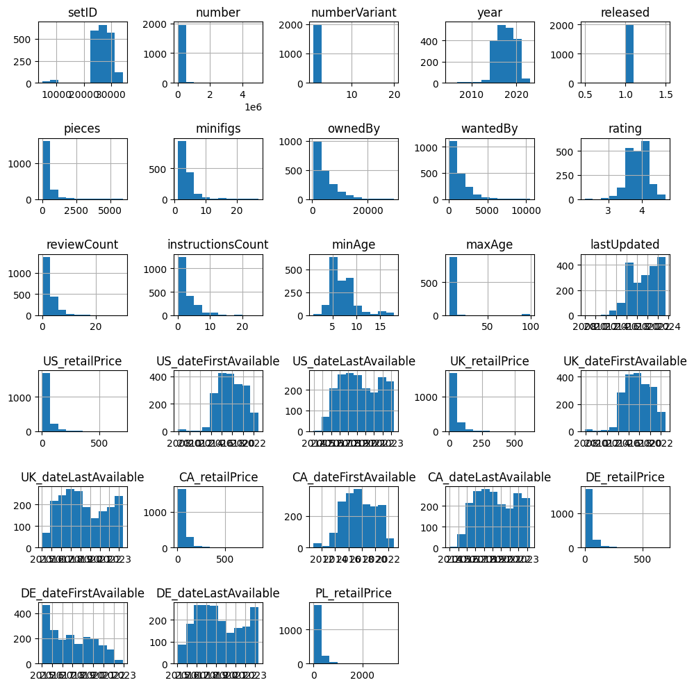

```python
import pandas as pd
import matplotlib.pyplot as plt

# Basic columns of the Data
print(df.columns)

# Basic statistics
print(df.describe())

df.hist(figsize=(10, 10))
plt.tight_layout()
plt.xticks(rotation=45)  # Rotate x-axis labels
plt.show()

# Boxplots for each column
#df.boxplot(figsize=(10, 10))
#plt.tight_layout()
#plt.xticks(rotation=90)  # Rotate x-axis labels
#plt.show()

# Correlation matrix
#corr = df.corr()
#plt.figure(figsize=(10, 10))
#plt.matshow(corr, fignum=1)
#plt.xticks(range(len(corr.columns)), corr.columns, rotation=90)
#plt.yticks(range(len(corr.columns)), corr.columns)
#plt.colorbar()
#plt.show()
```

UseFull to see the max

```python
#find max wanted by
max_wanted_by = df.iloc[df['wantedBy'].argmax()]
print(max_wanted_by)
```

```
setID                                                                 22807
number                                                                10236
numberVariant                                                             1
name                                                           Ewok Village
year                                                                   2013
theme                                                             Star Wars
themeGroup                                                         Licensed
subtheme                                          Ultimate Collector Series
category                                                             Normal
released                                                                  1
pieces                                                               1990.0
minifigs                                                               17.0
ownedBy                                                             13280.0
wantedBy                                                              10472
rating                                                                  4.5
reviewCount                                                               5
packagingType                                                           Box
availability                                                 LEGO exclusive
instructionsCount                                                         6
minAge                                                                 12.0
maxAge                                                                  NaN
tags                      ['C-3PO|n', 'Chewbacca|n', 'Chief Chirpa|n', '...
lastUpdated                                             2016-04-14 00:00:00
urlRetailPriceCheckPLN    https://promoklocki.pl/lego-star-wars-10236-wi...
US_retailPrice                                                       249.99
US_dateFirstAvailable                                   2013-09-01 00:00:00
US_dateLastAvailable                                    2016-11-29 00:00:00
UK_retailPrice                                                       199.99
UK_dateFirstAvailable                                   2013-09-01 00:00:00
UK_dateLastAvailable                                    2017-02-23 00:00:00
CA_retailPrice                                                       299.99
CA_dateFirstAvailable                                   2013-09-01 00:00:00
CA_dateLastAvailable                                    2016-11-28 00:00:00
DE_retailPrice                                                       249.99
DE_dateFirstAvailable                                   2015-01-14 00:00:00
DE_dateLastAvailable                                    2017-02-24 00:00:00
PL_retailPrice                                                      1199.99
Date                                                                2018-07
status                                                      Retired Product
Name: 53, dtype: object
```

### 3. Data Analysis

- Describe your data analysis and explain what you've learned about the dataset.
- If relevant, talk about your machine-learning.

```python
import os
import pandas as pd
import seaborn as sns
from src.loading_functions import load_or_download_lego_data,preprocess_data
import requests
import matplotlib.pyplot as plt
```

```python
#get cwd
cwd = os.getcwd()
#get data folder
data_folder = os.path.join(cwd, 'data')
```

```python
#load or download lego data and flags
dfall = load_or_download_lego_data(data_folder) #check if you have dependencies installed. else run first cell
df = preprocess_data(dfall,include_monthly=False)
dft= preprocess_data(dfall,include_monthly=True)
```

```
Loading data from c:\Users\viviK\Documents\GitHub\Lego projectfinal\MarcusGalea.github.io\data\lego_sets.csv
```

[output not shown]

We wanted to find out the difference between ownedBy and wantedBy. There is a big difference but in the end we decided that we care more about the wantedby since that is the value that ditermines the salability of an object. The OwnedBy we can hypothesis that shows the rarity of a set.

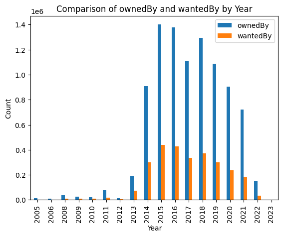

```python
# Visualisation NUMBER 1
# Group by 'year' and calculate the sum of 'ownedBy' and 'wantedBy'
grouped_df = df.groupby('year')[['ownedBy', 'wantedBy']].sum()

# Plot
grouped_df.plot(kind='bar', stacked=False)
plt.title('Comparison of ownedBy and wantedBy by Year')
plt.xlabel('Year')
plt.ylabel('Count')
plt.show()
```

Then two more graphs were made to indetify whether themes, of subthems where more intresting comparison. And what story is more helpful for the reader.

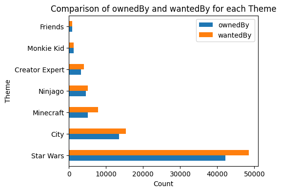

```python
# Visualisation NUMBER 2
# Filter the dataframe to include only rows where 'wantedBy' is higher than 'ownedBy'
filtered_df = df[df['wantedBy'] > df['ownedBy']]

# Group the filtered dataframe by 'theme' and calculate the sum of 'ownedBy' and 'wantedBy'
grouped_df = filtered_df.groupby('theme')[['ownedBy', 'wantedBy']].sum()

# Sort the grouped dataframe by the difference between 'wantedBy' and 'ownedBy'
grouped_df = grouped_df.sort_values(by=['wantedBy', 'ownedBy'], ascending=False)

# Create the horizontal bar plot
fig, ax = plt.subplots(figsize=(5, 4))
grouped_df[['ownedBy', 'wantedBy']].plot(kind='barh', ax=ax)

# Set the labels and title
ax.set_xlabel('Count')
ax.set_ylabel('Theme')
ax.set_title('Comparison of ownedBy and wantedBy for each Theme')

# Show the plot
plt.show()
```

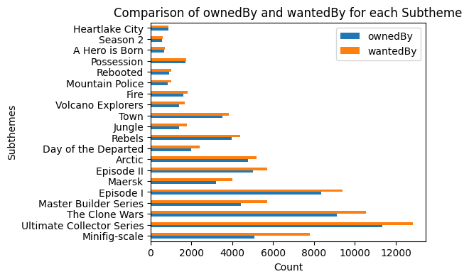

```python
# Visualisation NUMBER 3
# Filter the dataframe to include only rows where 'wantedBy' is higher than 'ownedBy'
filtered_df = df[df['wantedBy'] > df['ownedBy']]

# Group the filtered dataframe by 'theme' and calculate the sum of 'ownedBy' and 'wantedBy'
grouped_df = filtered_df.groupby('subtheme')[['ownedBy', 'wantedBy']].sum()

# Sort the grouped dataframe by the difference between 'wantedBy' and 'ownedBy'
grouped_df['difference'] = grouped_df['wantedBy'] - grouped_df['ownedBy']
grouped_df = grouped_df.sort_values('difference', ascending=False)

# Create the horizontal bar plot
fig, ax = plt.subplots(figsize=(5, 4))
grouped_df[['ownedBy', 'wantedBy']].plot(kind='barh', ax=ax)

# Set the labels and title
ax.set_xlabel('Count')
ax.set_ylabel('Subthemes')
ax.set_title('Comparison of ownedBy and wantedBy for each Subtheme')

# Show the plot
plt.show()
```

Then we made an interactive one with Themes

```python
# Visualisation NUMBER 4
# Filter the dataframe to include only rows where 'wantedBy' is higher than 'ownedBy'
filtered_df = df[df['wantedBy'] > df['ownedBy']]

# Group the filtered dataframe by 'theme' and calculate the sum of 'ownedBy' and 'wantedBy'
grouped_df = filtered_df.groupby('theme')[['ownedBy', 'wantedBy']].sum()

# Sort the grouped dataframe by the difference between 'wantedBy' and 'ownedBy'
grouped_df['difference'] = grouped_df['wantedBy'] - grouped_df['ownedBy']
grouped_df = grouped_df.sort_values('difference', ascending=False)

# Reset index to use 'subtheme' in ColumnDataSource
grouped_df = grouped_df.reset_index()

# Create a ColumnDataSource from df
source = ColumnDataSource(grouped_df)

# Create a new figure
p = figure(y_range=grouped_df['theme'], height=600, width=800, title='Comparison of ownedBy and wantedBy for each Theme')

# Create horizontal bar charts with specified colors
p.hbar(y=dodge('theme', -0.25, range=p.y_range), right='ownedBy', height=0.4, color="#add8e6", source=source, legend_label="ownedBy")  # Light blue
p.hbar(y=dodge('theme', 0.25, range=p.y_range), right='wantedBy', height=0.4, color="#ffa07a", source=source, legend_label="wantedBy")  # Light salmon

# Add a hover tool
hover = HoverTool(tooltips=[("ownedBy", "@ownedBy"), ("wantedBy", "@wantedBy")])
p.add_tools(hover)

# Move the legend to the upper right corner
p.legend.location = "top_right"

# Add interactivity to the legend
p.legend.click_policy = "hide"

# Show the plot
output_notebook()
show(p)
```

Loading BokehJS ...

Then an interactive model was made so create an interest for the user,. Also The user can select and deselect the wantedBy and OwnBy and hover over the diagram to see more specific. In the graph are included only the subthems that the wanted in higher than the owned so the user will kno the most valuable categories tio invest in.

```python
# Visualisation NUMBER 5
from bokeh.models import ColumnDataSource, HoverTool
from bokeh.plotting import figure, show
from bokeh.io import output_notebook
from bokeh.transform import dodge

# Filter the dataframe to include only rows where 'wantedBy' is higher than 'ownedBy'
filtered_df = df[df['wantedBy'] > df['ownedBy']]

# Group the filtered dataframe by 'theme' and calculate the sum of 'ownedBy' and 'wantedBy'
grouped_df = filtered_df.groupby('subtheme')[['ownedBy', 'wantedBy']].sum()

# Sort the grouped dataframe by the difference between 'wantedBy' and 'ownedBy'
grouped_df['difference'] = grouped_df['wantedBy'] - grouped_df['ownedBy']
grouped_df = grouped_df.sort_values('difference', ascending=False)

# Reset index to use 'subtheme' in ColumnDataSource
grouped_df = grouped_df.reset_index()

# Create a ColumnDataSource from df
source = ColumnDataSource(grouped_df)

# Create a new figure
p = figure(y_range=grouped_df['subtheme'], height=600, width=800, title='Comparison of ownedBy and wantedBy for each Subtheme')

# Create horizontal bar charts with specified colors
p.hbar(y=dodge('subtheme', -0.25, range=p.y_range), right='ownedBy', height=0.4, color="#add8e6", source=source, legend_label="ownedBy")  # Light blue
p.hbar(y=dodge('subtheme', 0.25, range=p.y_range), right='wantedBy', height=0.4, color="#ffa07a", source=source, legend_label="wantedBy")  # Light salmon

# Add a hover tool
hover = HoverTool(tooltips=[("ownedBy", "@ownedBy"), ("wantedBy", "@wantedBy")])
p.add_tools(hover)

# Move the legend to the upper right corner
p.legend.location = "top_right"

# Add interactivity to the legend
p.legend.click_policy = "hide"

# Show the plot
output_notebook()
show(p)
```

Loading BokehJS ...

```python
# Visualisation NUMBER 6
import plotly.graph_objects as go

top_20_set_names = df['name'].value_counts().nlargest(20)

fig = go.Figure()

# Loop through each set name in the top 20 set names
for set_name in top_20_set_names.index:
    set_dft = dft[dft['name'] == set_name]  # filter the DataFrame to include only the rows for this set
    fig.add_trace(go.Scatter(x=set_dft['Date'], y=set_dft['PriceMonthPLN'], mode='lines+markers', name=set_name))

fig.show()
```

[output not shown]

In the current plot the user can compare prices withing lego sets and understand how much the price of the set can change over time.

```python
# Visualisation NUMBER 7
from bokeh.plotting import figure, show
from bokeh.models import ColumnDataSource, HoverTool
from bokeh.palettes import Category20
import pandas as pd

# Convert 'Date' column to datetime if it's not already
dft['Date'] = pd.to_datetime(dft['Date'])

# Sort the DataFrame by 'Date'
dft = dft.sort_values('Date')

# Filter the DataFrame to include only rows where the subtheme is "Ultimate Collector Series"
ultimate_collector_df = df[df['subtheme'] == 'Ultimate Collector Series']

# Create a figure
p = figure(x_axis_type='datetime', title="Ultimate Collector Series - Price Changes", width=1000, height=600)

# Loop through each item in the Ultimate Collector Series
for i, item_name in enumerate(ultimate_collector_df['name'].unique()):
    item_data = dft[dft['name'] == item_name]

    # Create a ColumnDataSource for each item
    source = ColumnDataSource(data=dict(
        Date=item_data['Date'],
        PriceMonthPLN=item_data['PriceMonthPLN'],
        Name=[item_name] * len(item_data),
    ))

    # Plot the line
    p.line('Date', 'PriceMonthPLN', source=source, legend_label=item_name, line_color=Category20[20][i%20], visible=False)

    # Add circle markers
    p.circle('Date', 'PriceMonthPLN', source=source, size=6, color=Category20[20][i%20], legend_label=item_name, visible=False)

# Add hover tool
hover = HoverTool(tooltips=[("Name", "@Name"), ("Price", "@PriceMonthPLN{0.00}")])
p.add_tools(hover)

# Customize plot
p.xaxis.axis_label = "Date"
p.yaxis.axis_label = "Price (Euro)"
p.legend.location = "top_right"
p.legend.click_policy = "hide"  # Click on legend to hide/show lines

# Move legend outside of the plot area
p.legend.orientation = "vertical"
p.legend.border_line_alpha = 1
p.legend.background_fill_alpha = 1

# Adjust the size of the legend
p.legend.label_text_font_size = "10pt"

# Show the plot
show(p)
```

In this visualization we decide to use the available dates from each coutry so the user could understan the time window he had to buy a new lego set. It is also helful to see how much time an itel is available in the market before it moves on the the second had market.

```python
# Visualisation NUMBER 8
from bokeh.plotting import figure, show, output_file
from bokeh.models import ColumnDataSource
from bokeh.palettes import Spectral6

# Specify the output file
output_file("timewindow.html")

# Filter the DataFrame to include only rows where the subtheme is "Ultimate Collector Series"
ultimate_collector_df = df[df['subtheme'] == 'Ultimate Collector Series']

# Group the DataFrame by 'name' and get the first and last available dates for each product in each country
grouped_df = ultimate_collector_df.groupby('name').agg({
    'US_dateFirstAvailable': 'min', 'US_dateLastAvailable': 'max',
    'UK_dateFirstAvailable': 'min', 'UK_dateLastAvailable': 'max',
    'CA_dateFirstAvailable': 'min', 'CA_dateLastAvailable': 'max',
    'DE_dateFirstAvailable': 'min', 'DE_dateLastAvailable': 'max'
})

# Reset the index
grouped_df = grouped_df.reset_index()

# Convert the DataFrame to a ColumnDataSource
source = ColumnDataSource(grouped_df)

# Create a figure
p = figure(x_range=(grouped_df[['US_dateFirstAvailable', 'UK_dateFirstAvailable', 'CA_dateFirstAvailable', 'DE_dateFirstAvailable']].min().min(),
                    grouped_df[['US_dateLastAvailable', 'UK_dateLastAvailable', 'CA_dateLastAvailable', 'DE_dateLastAvailable']].max().max()),
           y_range=grouped_df['name'], height=600, width=800,
           title="Time window for Ultimate Collector Series products in Each Country",
           toolbar_location=None, tools="")

# Use hbar to create the colored rectangles for each country
p.hbar(y=dodge('name', -0.3, range=p.y_range), left='US_dateFirstAvailable', right='US_dateLastAvailable', height=0.2, color=Spectral6[0], source=source, legend_label='US')
p.hbar(y=dodge('name', -0.1, range=p.y_range), left='UK_dateFirstAvailable', right='UK_dateLastAvailable', height=0.2, color=Spectral6[1], source=source, legend_label='UK')
p.hbar(y=dodge('name', 0.1, range=p.y_range), left='CA_dateFirstAvailable', right='CA_dateLastAvailable', height=0.2, color=Spectral6[2], source=source, legend_label='CA')
p.hbar(y=dodge('name', 0.3, range=p.y_range), left='DE_dateFirstAvailable', right='DE_dateLastAvailable', height=0.2, color=Spectral6[3], source=source, legend_label='DE')

# Customize the plot
p.x_range.start = grouped_df[['US_dateFirstAvailable', 'UK_dateFirstAvailable', 'CA_dateFirstAvailable', 'DE_dateFirstAvailable']].min().min()
p.y_range.range_padding = 0.1
p.ygrid.grid_line_color = None
p.axis.minor_tick_line_color = None
p.outline_line_color = None
p.legend.location = "top_right"
p.legend.orientation = "vertical"

# Show the plot
show(p)
```

```python
#Setup for calender framework
df['Year'] = df['Date'].dt.year
df['Month'] = df['Date'].dt.month
grouped = df.groupby(['Year', 'Month', 'subtheme']).size().reset_index(name='Count')
# Define your threshold
threshold = 7
# Replace X with the desired value

# Filter the DataFrame
filtered = grouped[grouped['Count'] > threshold]
#convert dates to strings in filtered
filtered['Year'] = filtered['Year'].astype(str)
filtered['Month']=filtered['Month'].astype(str)
```

By changes the code we can have the visualization for three different years and have the most comon months of release

```python
from bokeh.models import ColumnDataSource, ColorBar, LinearColorMapper
from bokeh.plotting import figure, show
from bokeh.layouts import column
from bokeh.palettes import Viridis256
from bokeh.io import output_notebook,output_file
from math import pi


output_notebook()
output_file("calendar.html")

# Modify the 'Month' column to include the year
filtered['Month'] = filtered['Year'].astype(str) + ' ' + filtered['Month']

# Create a figure
subthemes = sorted(filtered['subtheme'].unique())
months_years = sorted(filtered['Month'].unique())
p = figure(x_range=months_years, y_range=list(reversed(subthemes)), toolbar_location=None, tools="",
           title="All Years <Combined")

# Rotate the x-axis labels
p.xaxis.major_label_orientation = pi/2

# Create a color mapper
mapper = LinearColorMapper(palette=Viridis256, low=filtered.Count.min(), high=filtered.Count.max())

# Create a rectangle glyph and add it to the figure
source = ColumnDataSource(data=filtered)
p.rect(x="Month", y="subtheme", width=1, height=1, source=source,
       fill_color={'field': 'Count', 'transform': mapper}, line_color=None)

# Create a color bar
color_bar = ColorBar(color_mapper=mapper, location=(0, 0), orientation='horizontal')
p.add_layout(color_bar, 'below')

# Show the figure
show(p)
```

Loading BokehJS ...

That one Vivi made it wasn t very usefull for the story and also there is a mistake with the logic behind the wantedBy since the sum is used and because of how the data are structed more sets sum up together than it should.

```python
# Visualisation NUMBER 10
import plotly.express as px

# Create a DataFrame with the most wanted subthemes
most_wanted_subthemes = df.groupby('subtheme')['wantedBy'].sum().reset_index()

# Sort by 'wantedBy' and select the top 15
most_wanted_subthemes = most_wanted_subthemes.sort_values('wantedBy', ascending=False).head(15)

# Merge with the original DataFrame to get the 'DE_retailPrice' and 'name' for each subtheme
merged_df = pd.merge(most_wanted_subthemes, df[['subtheme', 'DE_retailPrice', 'name']], on='subtheme', how='left')

# Create a vertical scatter plot
fig = px.scatter(merged_df, y='name', x='DE_retailPrice', color='wantedBy', title='Name vs DE Price by Most Wanted Subthemes')

fig.show()
```

[output not shown]

### 5. Visualizations.

- Explain the visualizations you've chosen.

We choose **visualizations 4,5,7,8.9** To support a story for the user.

- Why are they right for the story you want to tell?

The aim is to guide the user from a general understanding to a more specific one. **How popular can a set be?** In this segment, we aim to convey the importance of considering popular trends and cultural shifts, as LEGO both influences its target audience and is influenced by it.  
**Which subthemes are the most sought after?** In the following section, users are encouraged to explore specific subthemes to identify the most popular ones.  
**How much can a product's price change?** This metric serves as an indicator of how long one should wait before reselling a set back to the market.  
We aim to further educate the user about the typical release date and the timeframe during which a LEGO set remains available in the primary market before transitioning to the resale market."

### 4. Genre. Which genre of data story did you use?

[Segal and Heer paper](http://vis.stanford.edu/files/2010-Narrative-InfoVis.pdf)

To facilitate knowledge and confidence-building, our static data presentation adopts a magazine-style format. As users scroll down and read the article, they will gradually gain insights into how to initiate their research and what aspects they should investigate to make informed decisions. By adopting this approach, users can navigate through the content seamlessly, absorbing valuable information at their own pace. Additionally will include link with a site to continue with the exploraion with more data avalable to him.

- Which tools did you use from each of the 3 categories of Visual Narrative (Figure 7 in Segal and Heer). Why?
- Which tools did you use from each of the 3 categories of Narrative Structure (Figure 7 in Segal and Heer). Why?

We used from Visual Narrative Visual Structuring:

- **Consistent Visual Platform:** By maintaining a consistent visual style (e.g., fonts, colors, layout), you create a cohesive reading experience. Consistency helps users focus on the content without distractions. Highlighting:
- **Close-ups:** Using close-ups allows you to emphasize specific details within visualizations. For example, zooming in on a chart or graph can highlight critical data points Transition Guidance: We found the tools within this category to be somewhat inadequate for our dataset's needs.

We used from Visual Structuring:

- **Ordering:**
  - User-Directed Path: This approach lets users explore the content in a non-linear way. They can follow their interests, verifying information or diving deeper into specific aspects.
  - Linear: Linear ordering ensures a structured progression through the narrative. It’s useful when you want to control the sequence of information delivery.
- **Interactivity:**
  - Hover Highlighting: Interactive elements (like tooltips or hover effects) allow users to explore additional details. Hover highlighting can provide context or reveal hidden information.
  - Filtering: Users can filter data to focus on specific aspects. For instance, allowing users to filter by time period or category.
- **Messaging:**
  - Headlines: Clear headlines introduce each section, guiding users through the narrative.
  - Annotations: Annotations provide context or explanations alongside visualizations.
  - Accompanying Article: A well-written article complements visualizations, providing background, analysis, and interpretation.
  - Introductory Text: An engaging introduction sets the stage for the data story.
- Which tools did you use from each of the 3 categories of Narrative Structure (Figure 7 in Segal and Heer). Why? Ordering-->User Directed Path,linear,Interactivity--->Hover Highlighting ,Filtering, Messaging-->Headlines, annotations, accompanying Article, Introductory text, Summary

### 6. Discussion.

- What went well? We are satisfied with the coherence of the storyline this time around, and we believe we made good use of the data available, especially considering that the dataset was compiled from three different sources.
- What is still missing? What could be improved? Why?

One aspect we would like to improve is our time management. Additionally, if more time were available, we could implement animated checkpoints on the website to help users better understand the stages they are progressing through. We also aim to enhance the visualization of prices, allowing users to select subthemes and display different LEGO sets to explore more categories.

In summary, while we are pleased with the overall outcome, there are opportunities for improvement in time management and user experience enhancements.

### 7. Contributions. Who did what?

For this assignment, we functioned as a cohesive team, without assigning specific tasks initially. Instead, we adopted an iterative approach, focusing on one step at a time, aligning expectations and timelines, and then dividing tasks accordingly, like a sprint technic.

**Marcus** concentrated on ensuring the website's functionality and performance. He provided valuable assistance in problem-solving and troubleshooting, particularly with the program and various scripts. Additionally, Marcus developed the calendar visualization and undertook data cleaning after consulting with the team. He also organized the program files and provided guidance on GitHub usage.

**Lidia and Vivi** primarily focused on crafting the storyline and devising a coherent narrative based on the available data.

**Lidia** took charge of some visualizations, particularly the initial ones featuring themes, subthemes, and the available timeframe for purchasing an item new. She also authored the storyline for the website.

**Vivi**(Paraskevi) organized and composed the content for the explanatory notebook. Additionally, she worked on creating interactive visualizations showcasing specific LEGO sets and their price trends over time.